# The Art of Counting

September 30, 2019

## The art of counting

- **Working with corpora is much more than counting.** But counting words and lexical units is the basic operation for any more complex analysis, and may yield substantial results.
- **To count is to measure!** Is my measurement valid? Are there sufficient safeguards that I do measure what I intend to measure?
- **Statements about salience means to take the difference between absolute and relative frequencies serious.**. Frequencies are the the normalisation of counts by dividing counts by corpus/subcorpus size.
- **There is a wide variety of scenarios for counting:** We will focus on time series analysis and dictionary-based analyses.
- Basic methods for counting in the polmineR package are `count`, `dispersion` and `as.TermDocumentMatrix`. These methods are applicable for `corpus` and `subcorpus` objects. For the following example, we use the corpus of the verbatim records of the UN General Assembly.

```r
library(polmineR)
use("UNGA")
```

## Counting basics: The `count()`-method

- The most basic usage of the `count()`-method is to look up the number of occurrences of a search term (`query`) in a corpus.

```r
count("UNGA", query = "refugees")
##       query count         freq
## 1: refugees  6562 0.0001523474
```

- The column `count` reports the absolute number of observations, the column `freq` the relative frequency. The frequency results from a simple division of the absolute count by the corpus size.

```r
count("UNGA", query = "refugees")[["count"]] / size("UNGA")
## [1] 0.0001523474
```

- We can use a `character`-vector with several search terms.

```r
count("UNGA", query = c("refugees", "asylum"))
##       query count         freq
## 1: refugees  6562 1.523474e-04
## 2:   asylum   415 9.634893e-06
```

## Using regular expressions and CQP

- The `count()`-method will accept for the argument `query` the syntax of the Corpus Query Processor (CQP). One implication is that we can use regular expressions. The query needs to be put in single quotation marks, and the argument `cqp` is set to `TRUE`.

```r
count("UNGA", query = "'refugee.*'", cqp = TRUE) # mit CQP-Syntax
##          query count         freq
## 1: 'refugee.*'  7966 0.0001849435
```

- We can get a breakdown of the matches we have generated by setting the argument `breakdown` to `TRUE`.

```r
dt <- count("UNGA", query = "'refugee.*'", cqp = TRUE, breakdown = TRUE)
```

- The CQP syntax can also be used to match multi-word lexical units.

```r
dp <- count("UNGA", query = '"displaced" "persons"', cqp = TRUE)
```

## Matches for our regular expression

|  | query | match | count | share |
| --- | --- | --- | --- | --- |
| 1 | 'refugee.*' | refugees | 6562 | 82.38 |
| 2 | 'refugee.*' | refugee | 1398 | 17.55 |
| 3 | 'refugee.*' | refugee’s | 3 | 0.04 |
| 4 | 'refugee.*' | refugeegenerating | 1 | 0.01 |
| 5 | 'refugee.*' | refugeeprocessing | 1 | 0.01 |
| 6 | 'refugee.*' | refugeereceiving | 1 | 0.01 |

## Regular Expressions: Character classes

| Sign | Description |
| --- | --- |
| . | wildcard / matches any character |
| \d | “digit” (0 to 9) |
| \w | word character |
| \s | whitespace |

## Regular Expressions: Quantifiers

| Sign | Description |
| --- | --- |
| ? | Zero or one occurrences of the preceding element. |
| + | One or more occurrences of the preceding element. |
| * | Zero or more occurrences of the preceding element. |
| {n} | The preceding item is matched exactly n times. |
| {min,} | The preceding item is matched min or more times. |
| {min,max} | The preceding item is matched at least min times, but not more than max times. |

## Regular Expressions: Examples I

- This is sufficient to formulate queries that cover a broad set of cases.

```r
count("UNGA", query = '"refuge.*"', cqp = TRUE, breakdown = TRUE) %>% head(n = 3)
##         query    match count share
## 1: "refuge.*" refugees  6562 78.95
## 2: "refuge.*"  refugee  1398 16.82
## 3: "refuge.*"   refuge   339  4.08
```

- Alternative characters can be put in brackets …

```r
count("UNGA", query = '"[rR]efuge.*"', cqp = TRUE, breakdown = TRUE) %>% head(n = 3)
##            query    match count share
## 1: "[rR]efuge.*" refugees  6562 64.50
## 2: "[rR]efuge.*" Refugees  1815 17.84
## 3: "[rR]efuge.*"  refugee  1398 13.74
```

## Regular Expressions: Examples II

- Alternative formulations are wrapped in brackets and separated by the “|” sign.

```r
count("UNGA", query = '"(imm|em)igration.*"', breakdown = TRUE) %>% head()
##                   query        match count share
## 1: "(imm|em)igration.*"  immigration   525 78.71
## 2: "(imm|em)igration.*"   emigration   141 21.14
## 3: "(imm|em)igration.*" immigrations     1  0.15
```

## Querying the token stream

- Square brackets serve as a place holder for any token …

```r
count("UNGA", query = '"United" "Nations" "Commission" "for" []', cqp = T, breakdown = T)
##                                       query
## 1: "United" "Nations" "Commission" "for" []
## 2: "United" "Nations" "Commission" "for" []
## 3: "United" "Nations" "Commission" "for" []
##                                   match count share
## 1: United Nations Commission for Social     3 50.00
## 2:  United Nations Commission for India     2 33.33
## 3: United Nations Commission for Ruanda     1 16.67
```

- Curly brackets can be used as a quantifier …

```r
count("UNGA", query = '"[Rr]efugee.*" []{0,5} "burden"', cqp = TRUE, breakdown = TRUE) %>%
  head(n = 3) %>% subset(select = c("match", "count", "share"))
##                                 match count share
## 1:                     refugee burden     4 22.22
## 2:    refugees places an added burden     2 11.11
## 3: refugee population is a big burden     1  5.56
```

## Dispersion analysis

- Diachronic variation and synchronic change have a fundamental role for corpus analysis.
- The `dispersion()`-method serves as a tool to efficiently count over one or two dimensions.

```r
dt <- dispersion("UNGA", query = '"refugees"', s_attribute = "year")
head(dt) # wir betrachten nur den Anfang der Tabelle
```

```
##         query year count
## 1: "refugees" 1993     0
## 2: "refugees" 1994   384
## 3: "refugees" 1995   342
## 4: "refugees" 1996   342
## 5: "refugees" 1997   268
## 6: "refugees" 1998   344
```

- The `dispersion()`-method can process the CQP syntax just as the `count()`-method.

## Simple visualisation

- Let us get frequencies from the outset.

```r
dt <- dispersion("UNGA", query = '"refugee.*"', s_attribute = "year", freq = TRUE)
```

- We can visualise the result of our numerical analysis using a bar plot.

```r
barplot(
  height = dt[["freq"]] * 100000,
  names.arg = dt[["year"]],
  las = 2, ylab = "matches pro 100.000 Worte"
  )
```

## Refugees in the UN General Assembly

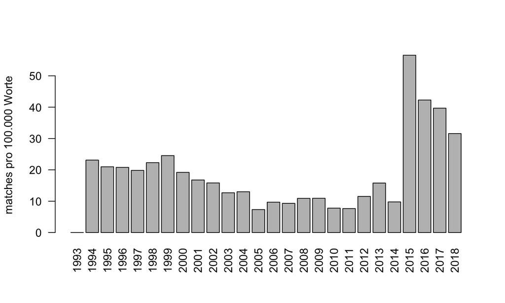

## From numbers to words

- To obtain valid judgements about the meaning of counts (in a time-series analysis), it will be necessary to inspect the context for the matches obtained.
- The `kwic()`-method (for keyword-in-context) serves this purpose. The basic usage is as follows.

```r
kwic("UNGA", query = '"[Rr]efugee.*"', cqp = TRUE)
```

- A more realistic scenario will be this one …

```r
k <- corpus("UNGA") %>%
  subset(year == "2015") %>%
  kwic(
    query = '"[Rr]efugee.*"', cqp = TRUE,
    left = 10, right = 10,
    s_attributes = c("state_organization", "year")
    )
```

## Concordances

|  | state_organization | year | left | node | right |
| --- | --- | --- | --- | --- | --- |
| 1 | NA | 2015 | trafficking in persons and injustice to workers , immigrants and | refugees | . In order to effectively eradicate slavery in all its |
| 2 | Indonesia | 2015 | , the Office of the United Nations High Commissioner for | Refugees | , the United Nations Office on Drugs and Crime , |
| 3 | Rwanda | 2015 | never forget the foreign friends who provided support to Chinese | refugees | following the massacre of Nanjing and other tragedies . We |
| 4 | Japan | 2015 | draft resolution entitled “ Status of internally displaced persons and | refugees | from Abkhazia , Georgia , and the Tskhinvali region / |
| 5 | Indonesia | 2015 | . The plight of the Georgian internally displaced persons and | refugees | dates back to the early 1990s . They were forced |
| 6 | Colombia | 2015 | the return of internally displaced persons ( IDPs ) and | refugees | to their homes . Our particular concern remains the continued |
| 7 | Cuba | 2015 | the right of safe and dignified return for IDPs and | refugees | from Abkhazia , Georgia , and the Tskhinvali region / |
| 8 | Philippines | 2015 | difficult situation of internally displaced persons ( IDPs ) and | refugees | from Abkhazia and the Tskhinvali region / South Ossetia , |
| 9 | Philippines | 2015 | draft resolution : the recognition of the right of all | refugees | and IDPs to return to their homes in Abkhazia and |
| 10 | Philippines | 2015 | forced demographic changes ; humanitarian access for all IDPs , | refugees | and other persons living within the conflict affected area ; |

[output cut: 1173 more lines]

## Questions / concerns

- Which metadata (i.e. display of s-attributes) do you need for your statements?
- How much word context (left and right tokens) do you need to arrive at findings?
- How do you think you could achieve intersubjectivity for you findings?
- Which workflow would support your work?

## Annotating KWIC results

- First, we get the kwic lines …

```r
refkwic <- corpus("UNGA") %>%
  subset(year == "1999") %>%
  kwic(query = '"refugee.*"', cqp = TRUE, left = 15, right = 15) %>%
  enrich(s_attribute = c("state_organization", "speaker"))
```

- Then we add an annotation layer …

```r
annotations(refkwic) <- list(name = "description", what = "")
```

- We then edit this result!

```r
edit(refkwic)
refkwic
```